# Practical Machine Learning– Activity Recognition Project

The goal of this project is to design a machine learning model by using the provided data from accelerometers on the belt, forearm, arm, and dumbbell of 6 participants and also implement the fitted model to predict activity for user feedbacks. The data set were collected from the participants who were asked to perform barbell lifts correctly and incorrectly in 5 different ways.

More information is available from the website here: http://groupware.les.inf.puc-rio.br/har (see the section on the Weight Lifting Exercise Dataset). The training data set ( https://d396qusza40orc.cloudfront.net/predmachlearn/pml-training.csv ) and the test data set ( https://d396qusza40orc.cloudfront.net/predmachlearn/pml-testing.csv ) are provided. The provided training set contains 19622 records with 160 variables is for training the model. And, the purpose of the test set of 20 records is to test the fitted model from this project to predict the suitable feedbacks for classification.

## *Model selection and implementing:*

Random Forest approach was chosen in the project to fit the model due to the characteristic noise in the sensor data. In order to optimize the fitted model, ntree was set to 150 and proximity and importance all were set to TRUE.

## *Results:*

The final results of random forests model on the training set are pretty impressive, the estimate of out-of-bag error rate is low (about 0.05). Below is the summary of the fitted model.

```
##
## Call:
##  randomForest(formula = training$classe ~ ., data = trainFinal,      ntree = 150, importance = TRUE, proximity = T)
##                Type of random forest: classification
##                      Number of trees: 150
## No. of variables tried at each split: 4
##
##         OOB estimate of  error rate: 4.34%
## Confusion matrix:
##      A    B    C    D    E class.error
## A 4086   33   34   20   12  0.02365591
## B   84 2679   61   10   14  0.05933989
## C   25   53 2439   35   15  0.04986365
## D   18   10  106 2264   14  0.06135987
## E   10   20   41   24 2611  0.03510717
```

The plots below show decreasing means of Accuracy of each features(Left) and decreasing mean Gini of each predictors(right)

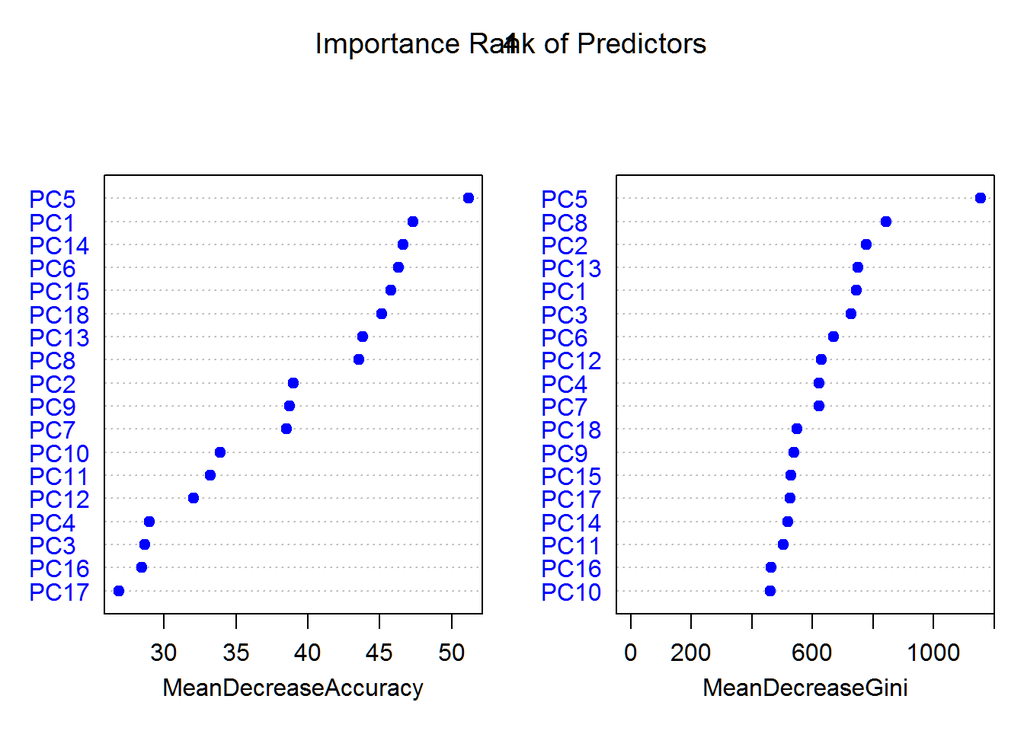

The plot below shows the relationship between Error rates and the number of Trees, the chosen number of trees of 150 is well justified.

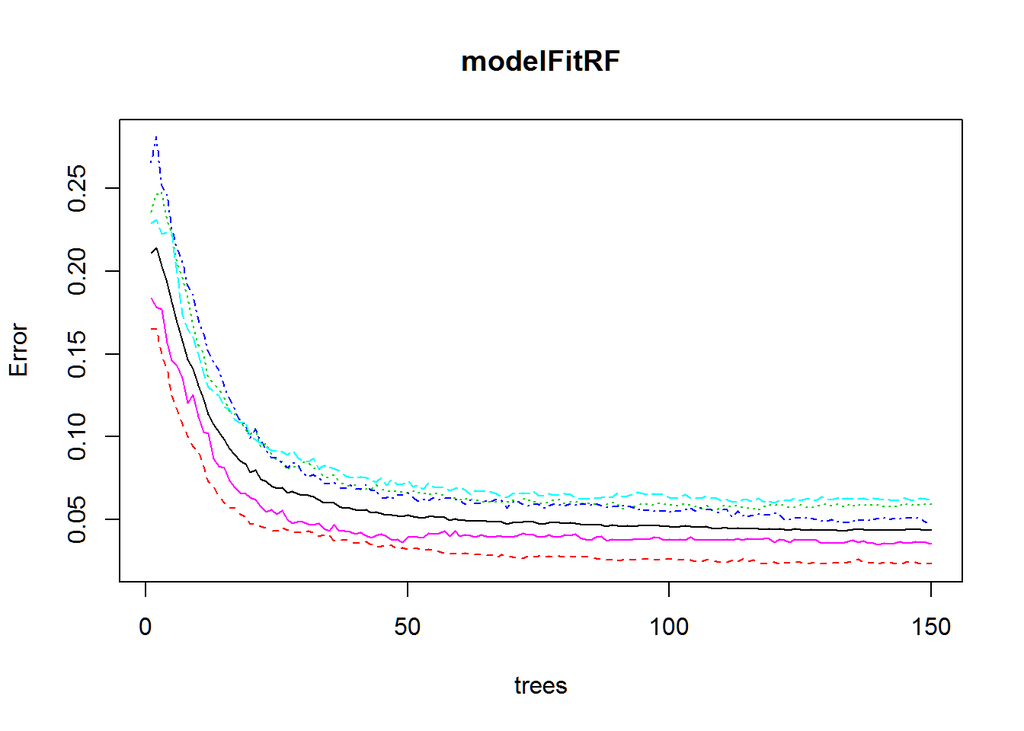

From the table of confusion matrix and statistics, it seems that the activities from the testig data set were grouped pretty nicely, only a few activities were not caught correctly by the classification model. The total Accuracy of predicition is around 0.95.

```
## Confusion Matrix and Statistics
##
##           Reference
## Prediction    A    B    C    D    E
##          A 1362   36   10    4    4
##          B   12  880   10    4   11
##          C   12   23  822   25   12
##          D    3    4   13  767    7
##          E    6    6    0    4  867
##
## Overall Statistics
##
##                Accuracy : 0.958
##                  95% CI : (0.952, 0.9634)
##     No Information Rate : 0.2845
##     P-Value [Acc > NIR] : < 2.2e-16
##
##                   Kappa : 0.9468
##  Mcnemar's Test P-Value : 8.674e-05
##
## Statistics by Class:
##
##                      Class: A Class: B Class: C Class: D Class: E
## Sensitivity            0.9763   0.9273   0.9614   0.9540   0.9623
## Specificity            0.9846   0.9906   0.9822   0.9934   0.9960
## Pos Pred Value         0.9619   0.9597   0.9195   0.9660   0.9819
## Neg Pred Value         0.9905   0.9827   0.9918   0.9910   0.9915
## Prevalence             0.2845   0.1935   0.1743   0.1639   0.1837
## Detection Rate         0.2777   0.1794   0.1676   0.1564   0.1768
## Detection Prevalence   0.2887   0.1870   0.1823   0.1619   0.1801
## Balanced Accuracy      0.9805   0.9590   0.9718   0.9737   0.9791
```

The expected values of the test set provided below. The values came out a little different for each run, and the most mistakes happened in detecting class B activity. Since the sensitivity of Class B is the lowest one, the result is expected

```
## [1] "The predictive classification of the test is "
```

```
##  1  2  3  4  5  6  7  8  9 10 11 12 13 14 15 16 17 18 19 20
##  B  A  A  A  A  E  D  B  A  A  A  C  B  A  E  E  A  B  B  B
## Levels: A B C D E
```

## *Conclusion*

From the results of misclassification error rates, I can conclude that random forest is a pretty good model for analyzing and predicting this qualitative activity recognition data set.

I used a lot of methods in caret package to clean and transform data set(e.g. “bagImp”,“nearZeroVar”,“pca”), but in the end I chosed to use simple randomForest() from randomForest package instead of randomForest method in caret package because of memory size problem. If the problem of memory size can be solved, further investigation might give us more possibilities.